# Ssd1 enrichment from normalizing to RNA-seq on full-length transcripts

Edward Wallace

6th Feb 2020

# Summary

This script is to make figures of relative *enrichment* of Ssd1 on mRNA, by processing time & condition matched RNA seq and Ssd1 CRAC data, crudely normalized to transcripts per million (TPM) on full-length transcripts.

This script relies on CRAC transcript counts produced by `multiBamCov` running in the CRAC pipeline, and found in `Ssd1_CRAC_demult_dedup_20190114_all/multicov_analyses/allsample_transcriptcounts.txt`. So it must be run after `src/CRAC_pipeline_SE_demult_dedup.py`, see the repository `README.md` for details.

This script also relies on RNA-seq transcript counts in `results/RNAseq_stressmatched_transcriptcounts.txt` produced by `multiBamCov`, running in `process_RNAseq.Rmd`. So this script must be run after `process_RNAseq.Rmd`.

Some of the figures rely on the lists of enriched genes from DESeq2 analysis, produced by the script `deseq2_Ssd1_CRAC_vs_RNAseq.Rmd`: * `Ssd1_enrichment_DeSeq2_30C_2x_padj0p05_genesonly.txt` * `Ssd1_enrichment_DeSeq2_42C_2x_padj0p05_genesonly.txt`

This analysis shows that:

- RNA-seq reads are highly reproducible between replicates
- Ssd1 reads are quite reproducible, but have low coverage
- The highest-enriched targets of Ssd1 are mRNAs encoding cell wall proteins.
- Stress protein mRNAs that are most induced by heat shock are *not enriched* in Ssd1 binding, although they are bound by Ssd1.

Both RNAseq and Ssd1-CRAC are quantified on *full-length estimated unspliced transcripts* using bedtools multicov after genomic alignment with novoalign. This has some problems. For example, reads on 2 overlapping transcripts are counted on *both*, if the UTRs or ORFs overlap.

Note that this analysis:

- is restricted to mRNAs encoding verified ORFs froms nuclear chromosomes: no mitochondrial chromosome or ncRNAs.
- uses Pelechano 2013 “most abundant” annotation of transcript ends, and adds a default 25nt 5’UTR and 125nt 3’UTR for transcripts not annotated in Pelechano 2013.
- normalises count density by transcript length, to give Transcripts Per Million (TPM).
- has different goals and a cruder statistical model than the DESeq2 analysis in `deseq2_Ssd1_CRAC_vs_RNAseq.Rmd`.

# Inspecting RNA-seq count data

## Load RNA-seq count data

```r
counts_RNA_stranded <- read_tsv("../results/RNAseq_stressmatched_transcriptcounts.txt",
                                comment = "#")  %>%
  mutate(Gene=gene_from_attr(attributes))

tpms_RNA_stranded <-  counts_RNA_stranded %>%
  select(Gene, RNA_A_30,RNA_B_30,RNA_C_GE,RNA_D_GE,RNA_E_42,RNA_F_42) %>%
  mutate_if(is.numeric,
            calc_tpm,
            eff_length = counts_RNA_stranded$end - counts_RNA_stranded$start)
```

## Scatter plot shows genewise CPMS are VERY reproducible

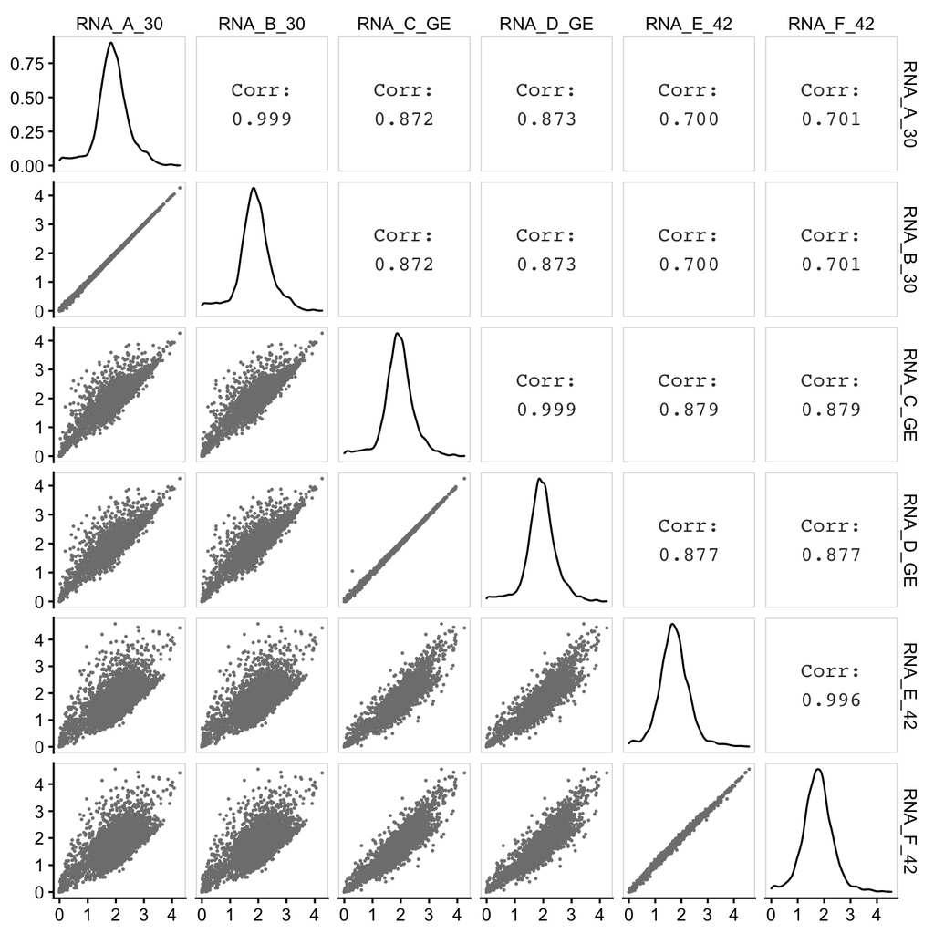

```r
counts_RNA_stranded %>%
  select(RNA_A_30,RNA_B_30,RNA_C_GE,RNA_D_GE,RNA_E_42,RNA_F_42) %>%
  mutate_all(calc_cpm) %>%
  mutate_all(log10plusepsilon) %>%
  ggpairs_genewise()
```

## Scatter plot shows genewise TPMs are likewise very reproducible

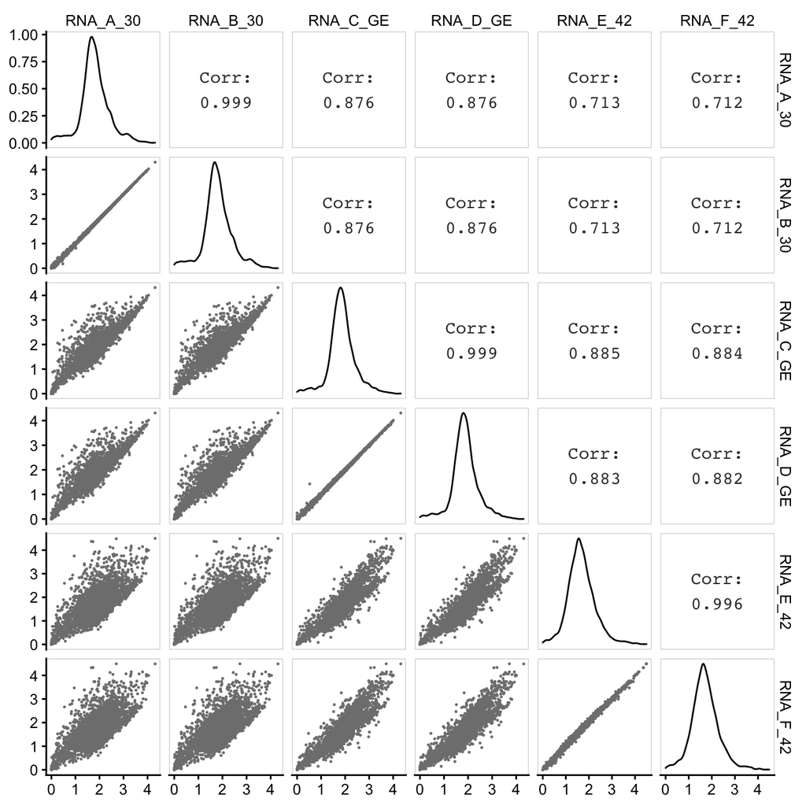

```r
tpms_RNA_stranded %>%
  select(RNA_A_30,RNA_B_30,RNA_C_GE,RNA_D_GE,RNA_E_42,RNA_F_42) %>%
  mutate_all(log10plusepsilon,epsilon=1) %>%
  ggpairs_genewise()
```

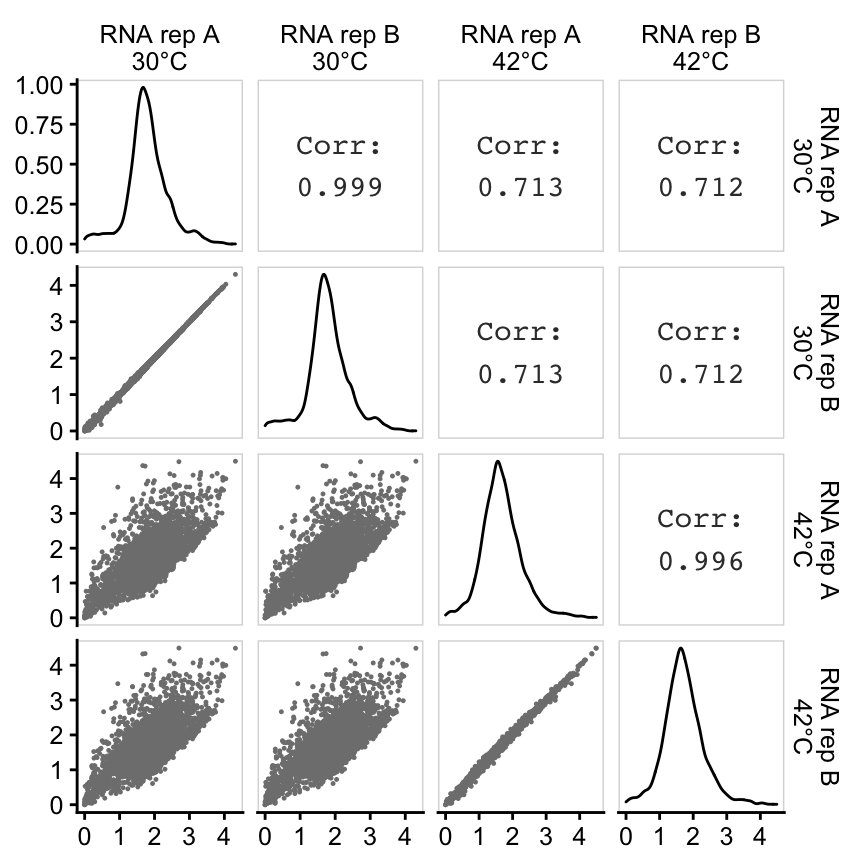

```r
tpms_RNA_stranded %>%
  select("RNA rep A\n30°C" = RNA_A_30,
         "RNA rep B\n30°C" = RNA_B_30,
         "RNA rep A\n42°C" = RNA_E_42,
         "RNA rep B\n42°C" = RNA_F_42) %>%
  mutate_all(log10plusepsilon,epsilon=1) %>%
  ggpairs_genewise()
```

# Inspecting Ssd1-bound data at genewise level

## Load Ssd1-bound genewise counts

```r
counts_Ssd1_stranded <- read_tsv("../Ssd1_CRAC_demult_dedup_20190114_all/multicov_analyses/allsample_transcriptcounts.txt",
                                 comment = "#") %>%
  mutate(Gene=gene_from_attr(attributes))%>%
  select(Gene,seqname,feature,start,end,attributes,
         Ssd1_3_30 = `20190114_Ssd1_CRAC_trimmed_NNNGTGAGC_SSD1_3_30.bam`,
         Ssd1_4_30 = `20190114_Ssd1_CRAC_trimmed_NNNTGGAGC_SSD1_4_30.bam`,
         Ssd1_3_42 = `20190114_Ssd1_CRAC_trimmed_NNNAGAGC_SSD1_3_42.bam`,
         Ssd1_4_42 = `20190114_Ssd1_CRAC_trimmed_NNNCTAGC_SSD1_4_42.bam`,
         BY4741 = `20190114_Ssd1_CRAC_trimmed_NNNGACTTAGC_BY4741.bam`)

# rename: ("Ssd1_3_30","Ssd1_4_30","Ssd1_3_42","Ssd1_4_42", "BY4741"))

tpms_Ssd1_stranded <-  counts_Ssd1_stranded %>%
  select(Gene, Ssd1_3_30,Ssd1_4_30,Ssd1_3_42,Ssd1_4_42,BY4741) %>%
  mutate_if(is.numeric,
            calc_tpm,
            eff_length = counts_Ssd1_stranded$end - counts_Ssd1_stranded$start)
```

```r
counts_Ssd1_stranded
```

```
## # A tibble: 5,090 x 11
##    Gene  seqname feature  start    end attributes Ssd1_3_30 Ssd1_4_30 Ssd1_3_42
##    <chr> <chr>   <chr>    <dbl>  <dbl> <chr>          <dbl>     <dbl>     <dbl>
##  1 YAL0… chrI    primar… 147469 151191 ID=YAL001…        25         0        49
##  2 YAL0… chrI    primar… 143682 147656 ID=YAL002…        16        15        10
##  3 YAL0… chrI    primar… 142153 143381 ypd=4653;…       410       183       302
##  4 YAL0… chrI    primar… 139357 141493 ypd=236;I…       273       115      1961
##  5 YAL0… chrI    primar… 137552 138414 ypd=203;I…        17         9         1
##  6 YAL0… chrI    primar… 136866 137637 ypd=146;I…         0         0        19
##  7 YAL0… chrI    primar… 135823 136756 ypd=6;ID=…         4         0         5
##  8 YAL0… chrI    primar… 134025 135699 ypd=2;ID=…         8         4         9
##  9 YAL0… chrI    primar… 132195 134173 ypd=3;ID=…         1         9         0
## 10 YAL0… chrI    primar… 130735 132082 ypd=667;I…        39        42        59
## # … with 5,080 more rows, and 2 more variables: Ssd1_4_42 <dbl>, BY4741 <dbl>
```

## Ssd1-bound genewise CPMs are reproducible

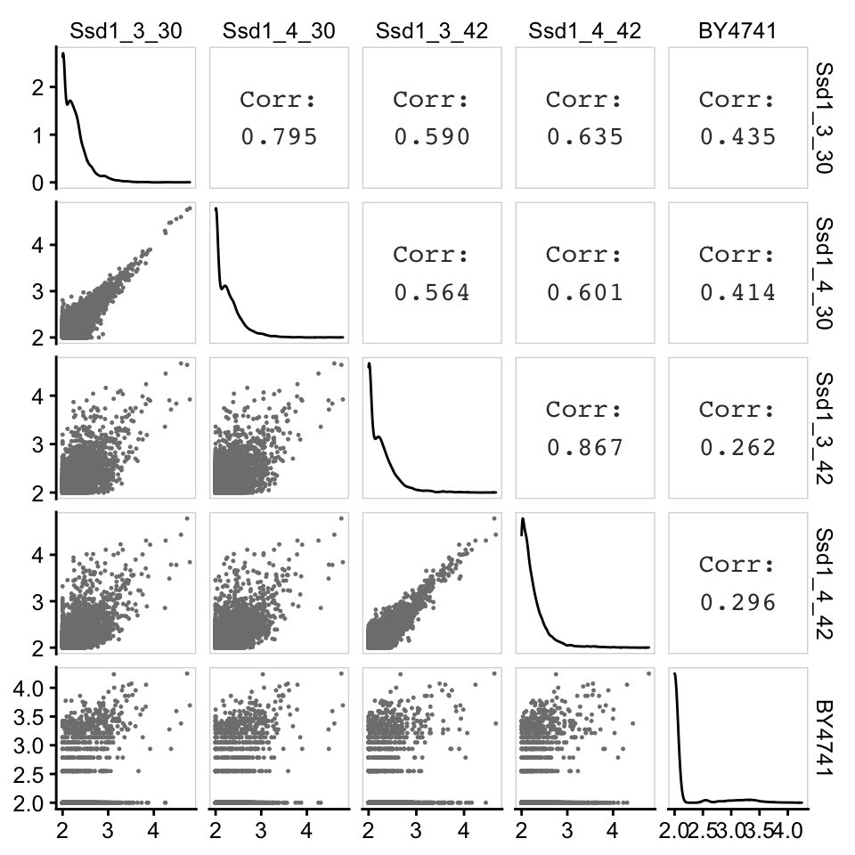

```r
counts_Ssd1_stranded %>%
  select(Ssd1_3_30,Ssd1_4_30,Ssd1_3_42,Ssd1_4_42,BY4741) %>%
  mutate_all(calc_cpm) %>%
  mutate_all(log10plusepsilon,epsilon=100) %>%
  ggpairs_genewise()
```

This is not as reproducible as the RNA-seq, due to relatively low coverage of deduplicated reads.

## Ssd1-bound genewise TPMs are reproducible

Here transform TPMs by `log10(tpm + 10)`, where the `+ 10` smooths away some of the low-count noise.

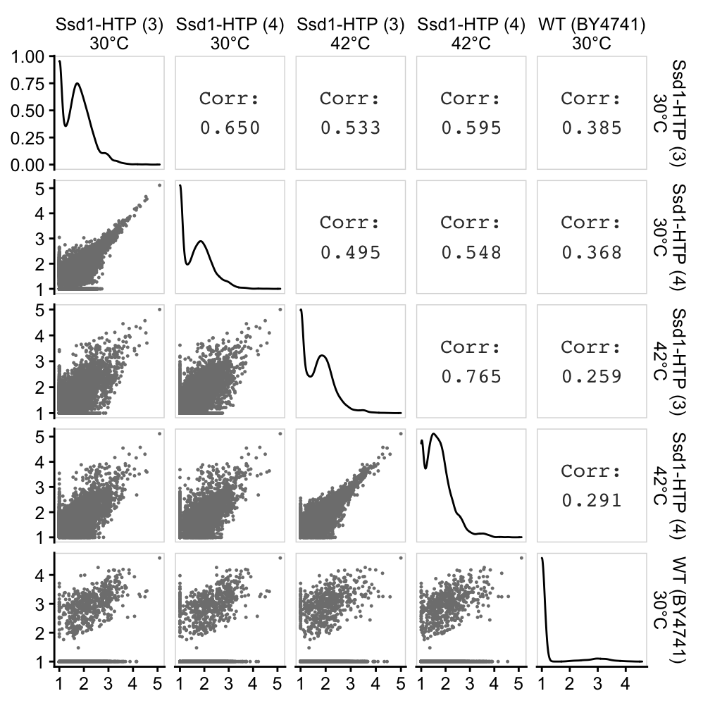

```r
tpms_Ssd1_stranded %>%
  select("Ssd1-HTP (3)\n30°C" = Ssd1_3_30,
         "Ssd1-HTP (4)\n30°C" = Ssd1_4_30,
         "Ssd1-HTP (3)\n42°C" = Ssd1_3_42,
         "Ssd1-HTP (4)\n42°C" = Ssd1_4_42,
         "WT (BY4741)\n30°C" = BY4741) %>%
  mutate_all(log10plusepsilon,epsilon=10) %>%
  ggpairs_genewise()
```

# Compare Ssd1 CRAC to RNA-seq data to estimate crude enrichment

## Construct a single table containing Ssd1-bound and RNA-seq counts

We:

- melt/pivot the data to get in tidy long format
- make average TPMs per condition
- join these “average TPMs per condition” for Ssd1 and RNA
- calculate a ratio of TPMs; this is crude as it’s normalised by total counts only
- add gene names from SGD
- confirm that TPM normalization correct by checking that TPMs sum to 1000000.

### Melt the data frames and summarize (assigned) TPMs per sample

```r
tpms_RNA_melt <-
  tpms_RNA_stranded %>%
  gather(key="Sample",value="TPM",-Gene)

tpms_RNA_melt %>% group_by(Sample) %>% summarize(TPM=sum(TPM))
```

```
## # A tibble: 6 x 2
##   Sample        TPM
##   <chr>       <dbl>
## 1 RNA_A_30 1000000.
## 2 RNA_B_30 1000000
## 3 RNA_C_GE 1000000
## 4 RNA_D_GE 1000000
## 5 RNA_E_42 1000000
## 6 RNA_F_42 1000000.
```

```r
tpms_Ssd1_melt <-
  tpms_Ssd1_stranded %>%
  gather(key="Sample",value="TPM",-Gene)

tpms_Ssd1_melt  %>% group_by(Sample) %>% summarize(TPM=sum(TPM))
```

```
## # A tibble: 5 x 2
##   Sample         TPM
##   <chr>        <dbl>
## 1 BY4741    1000000
## 2 Ssd1_3_30 1000000
## 3 Ssd1_3_42 1000000.
## 4 Ssd1_4_30 1000000
## 5 Ssd1_4_42 1000000
```

### Calculate average TPMs and join

```r
scer_mrna_prot <- read_tsv("../input_annotation/scer-mrna-protein-absolute-estimate.txt",
                           comment="#") %>%
  rename(Gene=orf,Name=gene)

tpm_RNA_bycondition <-
  tpms_RNA_melt %>%
  separate(Sample,c("SType","Rep","Condition")) %>%
  group_by(Gene,Condition) %>%
  summarize(TPM.mean = mean(TPM,na.rm=TRUE))

tpm_Ssd1_bycondition <-
  tpms_Ssd1_melt %>%
  separate(Sample,c("SType","Rep","Condition")) %>%
  group_by(Gene,Condition) %>%
  summarize(TPM.mean = mean(TPM,na.rm=TRUE))

tpm_join_bycondition <-
  full_join( tpm_RNA_bycondition %>% filter(Condition %in% c("30","42")),
              tpm_Ssd1_bycondition %>% filter(Condition %in% c("30","42")),
              by=c("Gene","Condition"),
              suffix=c(".RNA",".Ssd1")) %>%
  mutate(ratio.Ssd1.RNA = TPM.mean.Ssd1/TPM.mean.RNA) %>%
  left_join(scer_mrna_prot %>% select(Gene,Name)) %>%
  mutate(Condition = factor(Condition,
                            levels = c("30","42"),
                            labels = c("30°C","42°C"))
  ) %>%
  select(Gene,Name,Condition,
         TPM.RNA=TPM.mean.RNA,TPM.Ssd1=TPM.mean.Ssd1,
         ratio.Ssd1.RNA)
```

### What the TPM joined data look like

```r
tpm_join_bycondition
```

```
## # A tibble: 10,180 x 6
## # Groups:   Gene [5,090]
##    Gene    Name  Condition TPM.RNA TPM.Ssd1 ratio.Ssd1.RNA
##    <chr>   <chr> <fct>       <dbl>    <dbl>          <dbl>
##  1 YAL001C TFC3  30°C         38.6     22.8          0.590
##  2 YAL001C TFC3  42°C         42.5     56.9          1.34
##  3 YAL002W VPS8  30°C         23.7     34.1          1.44
##  4 YAL002W VPS8  42°C         18.6     13.6          0.732
##  5 YAL003W EFB1  30°C       1880.    1940.           1.03
##  6 YAL003W EFB1  42°C       2563.    1688.           0.659
##  7 YAL005C SSA1  30°C       1242.     725.           0.584
##  8 YAL005C SSA1  42°C      12064.    6180.           0.512
##  9 YAL007C ERP2  30°C        245.     123.           0.504
## 10 YAL007C ERP2  42°C        115.      21.9          0.191
## # … with 10,170 more rows
```

## Plot TPMs by condition, Ssd1-bound vs RNA, with some labels

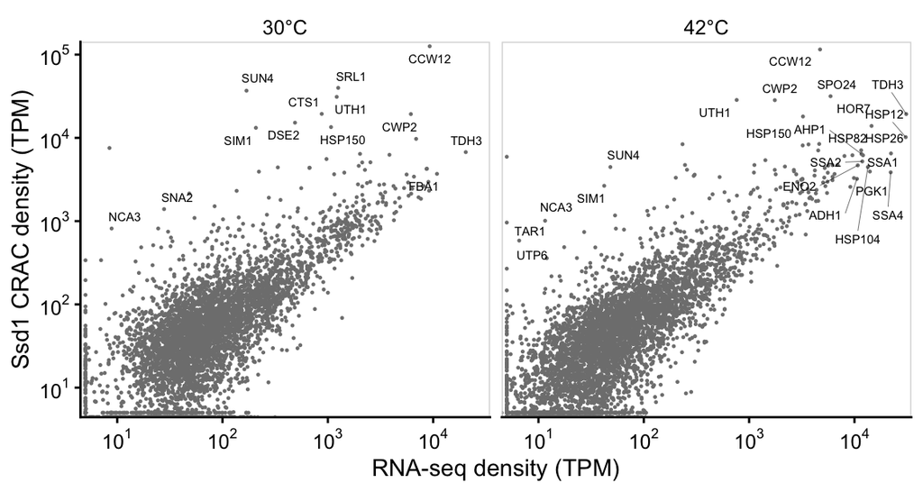

```r
ggplot(data=tpm_join_bycondition,aes(x=TPM.RNA,y=TPM.Ssd1)) +
  geom_point(size=0.2,colour="grey50") +
  ggrepel::geom_text_repel(
    data=
      tpm_join_bycondition %>%
      filter(TPM.RNA > 10000 | TPM.Ssd1 > 10000 |
               (ratio.Ssd1.RNA > 50 & TPM.Ssd1 > 500) ),
    aes(label=Name),size=2,
    label.padding=0.02,segment.size=0.1,force=0.1,
    # set random number seed so the labels go in the same place every time
    seed = 42) +
  scale_x_log10_sci("RNA-seq density (TPM)",
                limits=c(5,max(tpm_join_bycondition$TPM.RNA)),
                oob=scales::squish,expand=c(0.01,0.01)) +
  scale_y_log10_sci("Ssd1 CRAC density (TPM)",
                limits=c(5,max(tpm_join_bycondition$TPM.Ssd1)),
                oob=scales::squish,expand=c(0.01,0.01)) +
  facet_wrap(~Condition)
```

## Ssd1-enriched genes by crude TPM ratios

These are familiar from other datasets: TOS1, TOS6, SUN4/SIM1/UTH1/SRL1, etc.

```r
tpm_join_bycondition %>%
  filter(Condition=="30°C",TPM.RNA > 20) %>%
  arrange(desc(ratio.Ssd1.RNA))
```

```
## # A tibble: 4,391 x 6
## # Groups:   Gene [4,391]
##    Gene      Name  Condition TPM.RNA TPM.Ssd1 ratio.Ssd1.RNA
##    <chr>     <chr> <fct>       <dbl>    <dbl>          <dbl>
##  1 YNL066W   SUN4  30°C        169.    36856.          218.
##  2 YIL123W   SIM1  30°C        207.    13206.           63.7
##  3 YDR525W-A SNA2  30°C         27.9    1395.           50.1
##  4 YGR041W   BUD9  30°C         48.4    2146.           44.4
##  5 YIL042C   PKP1  30°C         24.5     816.           33.3
##  6 YOR247W   SRL1  30°C       1253.    39858.           31.8
##  7 YHR143W   DSE2  30°C        488.    15218.           31.2
##  8 YKR042W   UTH1  30°C       1214.    31076.           25.6
##  9 YDR441C   APT2  30°C         30.4     747.           24.6
## 10 YER046W   SPO73 30°C         22.0     513.           23.4
## # … with 4,381 more rows
```

```r
tpm_join_bycondition %>%
  filter(Condition=="42°C",TPM.RNA > 20) %>%
  arrange(desc(ratio.Ssd1.RNA))
```

```
## # A tibble: 3,882 x 6
## # Groups:   Gene [3,882]
##    Gene      Name  Condition TPM.RNA TPM.Ssd1 ratio.Ssd1.RNA
##    <chr>     <chr> <fct>       <dbl>    <dbl>          <dbl>
##  1 YNL066W   SUN4  42°C         48.1    4463.           92.7
##  2 YIL123W   SIM1  42°C         42.1    2657.           63.1
##  3 YKR042W   UTH1  42°C        762.    28523.           37.4
##  4 YOR247W   SRL1  42°C        233.     8392.           36.0
##  5 YDR528W   HLR1  42°C         27.1     740.           27.3
##  6 YLR110C   CCW12 42°C       4714.   115227.           24.4
##  7 YDR525W-A SNA2  42°C         53.3    1171.           22.0
##  8 YHR071W   PCL5  42°C        246.     4725.           19.2
##  9 YGR279C   SCW4  42°C        201.     3322.           16.5
## 10 YKL096W-A CWP2  42°C       1754.    28365.           16.2
## # … with 3,872 more rows
```

### Make output files for crude Ssd1-enriched genes over 4x

We conservatively report transcripts that are at least 4-fold enriched in Ssd1 CRAC reads compared to RNA-seq, and with at least 20 TPM in the RNA-seq data. This filters out low-expressed genes with noisy counts.

```r
Ssd1_targets_TPMratio4x_30C <-
  tpm_join_bycondition %>%
  filter(Condition=="30°C",TPM.RNA > 20, ratio.Ssd1.RNA > 4) %>%
  arrange(desc(ratio.Ssd1.RNA))

write_tsv(x = Ssd1_targets_TPMratio4x_30C %>%
            select(-Condition) %>%
            mutate_if(is.numeric, round, digits = 3),
          path="../results/Ssd1_targets_TPMratio4x_30C.txt")

Ssd1_targets_TPMratio4x_42C <-
  tpm_join_bycondition %>%
  filter(Condition=="42°C",TPM.RNA > 20, ratio.Ssd1.RNA > 4) %>%
  arrange(desc(ratio.Ssd1.RNA))

write_tsv(x = Ssd1_targets_TPMratio4x_42C %>%
            select(-Condition) %>%
            mutate_if(is.numeric, round, digits = 3),
          path="../results/Ssd1_targets_TPMratio4x_42C.txt")
```

## Which genes are enriched at 42C not 30C?

```r
Ssd1_targets_TPMratio4x_42C %>%
  filter(! Gene %in% Ssd1_targets_TPMratio4x_30C$Gene)
```

```
## # A tibble: 33 x 6
## # Groups:   Gene [33]
##    Gene      Name  Condition TPM.RNA TPM.Ssd1 ratio.Ssd1.RNA
##    <chr>     <chr> <fct>       <dbl>    <dbl>          <dbl>
##  1 YKL096W-A CWP2  42°C       1754.    28365.          16.2
##  2 YOL026C   MIM1  42°C        110.     1179.          10.7
##  3 YNL283C   WSC2  42°C         39.5     393.           9.95
##  4 YLR297W   <NA>  42°C         28.3     274.           9.66
##  5 YFR017C   IGD1  42°C        167.     1485.           8.91
##  6 YDR309C   GIC2  42°C         51.0     364.           7.13
##  7 YML041C   VPS71 42°C         32.4     223.           6.86
##  8 YPR138C   MEP3  42°C         35.2     238.           6.76
##  9 YER039C   HVG1  42°C         28.1     188.           6.69
## 10 YOR178C   GAC1  42°C         35.8     236.           6.59
## # … with 23 more rows
```

## Which genes are enriched at 30C not 42C?

```r
Ssd1_targets_TPMratio4x_30C %>%
  filter(! Gene %in% Ssd1_targets_TPMratio4x_42C$Gene)
```

```
## # A tibble: 49 x 6
## # Groups:   Gene [49]
##    Gene    Name  Condition TPM.RNA TPM.Ssd1 ratio.Ssd1.RNA
##    <chr>   <chr> <fct>       <dbl>    <dbl>          <dbl>
##  1 YGR041W BUD9  30°C         48.4    2146.          44.4
##  2 YDR441C APT2  30°C         30.4     747.          24.6
##  3 YHR167W THP2  30°C         26.2     483.          18.5
##  4 YKL061W BLI1  30°C         49.9     547.          11.0
##  5 YIL134W FLX1  30°C         21.8     202.           9.30
##  6 YGR014W MSB2  30°C         92.4     829.           8.97
##  7 YDR449C UTP6  30°C         71.8     618.           8.60
##  8 YPL076W GPI2  30°C         22.4     191.           8.50
##  9 YJR147W HMS2  30°C         68.0     573.           8.43
## 10 YCL037C SRO9  30°C         32.1     264.           8.21
## # … with 39 more rows
```

## The highest-expressed genes at 42C are not enriched in Ssd1 binding

```r
tpm_join_bycondition %>%
  filter(Condition=="42°C") %>%
  arrange(desc(TPM.RNA))
```

```
## # A tibble: 5,090 x 6
## # Groups:   Gene [5,090]
##    Gene      Name   Condition TPM.RNA TPM.Ssd1 ratio.Ssd1.RNA
##    <chr>     <chr>  <fct>       <dbl>    <dbl>          <dbl>
##  1 YGR192C   TDH3   42°C       31026.   19309.          0.622
##  2 YFL014W   HSP12  42°C       30667.   10196.          0.332
##  3 YBR072W   HSP26  42°C       22231.    6502.          0.292
##  4 YER103W   SSA4   42°C       22095.    3857.          0.175
##  5 YMR251W-A HOR7   42°C       14528.   13904.          0.957
##  6 YCR012W   PGK1   42°C       14014.    3940.          0.281
##  7 YLL026W   HSP104 42°C       13415.    4463.          0.333
##  8 YAL005C   SSA1   42°C       12064.    6180.          0.512
##  9 YLL024C   SSA2   42°C       11868.    5216.          0.439
## 10 YLR109W   AHP1   42°C       11658.    6400.          0.549
## # … with 5,080 more rows
```

These,e.g. Hsp104, aren’t enriched in Ssd1 binding.

## Highly-expressed genes at 42C *over 2x* enriched in Ssd1 binding

```r
tpm_join_bycondition %>%
  filter(Condition=="42°C",ratio.Ssd1.RNA > 2) %>%
  arrange(desc(TPM.RNA))
```

```
## # A tibble: 663 x 6
## # Groups:   Gene [663]
##    Gene      Name   Condition TPM.RNA TPM.Ssd1 ratio.Ssd1.RNA
##    <chr>     <chr>  <fct>       <dbl>    <dbl>          <dbl>
##  1 YPR036W-A SPO24  42°C        5927.   31629.           5.34
##  2 YLR110C   CCW12  42°C        4714.  115227.          24.4
##  3 YJR104C   SOD1   42°C        3663.    8347.           2.28
##  4 YJL159W   HSP150 42°C        3245.   18054.           5.56
##  5 YML028W   TSA1   42°C        3226.    8110.           2.51
##  6 YER150W   SPI1   42°C        2187.    4524.           2.07
##  7 YBR067C   TIP1   42°C        1788.    3649.           2.04
##  8 YKL096W-A CWP2   42°C        1754.   28365.          16.2
##  9 YDL133C-A RPL41B 42°C        1752.    4126.           2.36
## 10 YPL250C   ICY2   42°C        1426.    5394.           3.78
## # … with 653 more rows
```

- SPO24 again
- TSA1/SOD1 involved in oxidative stress resistance
- CCW12/CWP1/TIP1/BGL2 stress-induced cell wall proteins
- YDR524C-B Putative protein of unknown function; SWAT-GFP and mCherry fusion proteins localize to the endoplasmic reticulum

## Plot TPMs by condition, DEseq2-enriched genes labeled

This is figure panel 4C of the manuscript, output to the file `../figure_out/Ssd1CRAC_vs_RNAseq_TPM_colourlabels.pdf`.

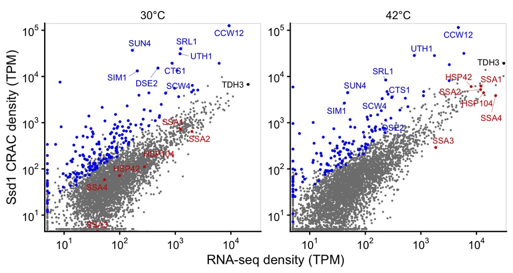

```r
# We had a longer and harder to follow list of 16 targets, that is commented out here; slimmed down to 8 select for a more readable figure
# Ssd1_common_targets_df <-
#   readr::read_tsv("../results/Ssd1_targets_common_Hogan_Jansen_Bayne30C.txt",
#                   comment = "#")
#
# Ssd1_targets_16select <- c(Ssd1_common_targets_df$Name, c("CCW12","CWP2","SPO24","NCA3"))

Ssd1_targets_8select <- c("CTS1","DSE2","SIM1","SUN4","UTH1","SCW4","CCW12","SRL1")

Ssd1_targets_DESeq2_2x_p0p05 <- bind_rows(
  tibble(Gene = readr::read_lines("../results/Ssd1_enrichment_DeSeq2_30C_2x_padj0p05_genesonly.txt"),
         Condition = "30"),
  tibble(Gene = readr::read_lines("../results/Ssd1_enrichment_DeSeq2_42C_2x_padj0p05_genesonly.txt"),
         Condition = "42")) %>%
  dplyr::mutate(Condition = factor(Condition,
                            levels = c("30","42"),
                            labels = c("30°C","42°C")),
                GType = "Ssd1_target"
                )

HSPs_select <- c("HSP42","HSP104","SSA1","SSA2","SSA3","SSA4")

Abundant_genes_select <- c("TDH3")

select_genetype_df <- bind_rows(
  tibble(GType = "Ssd1_target", Name = Ssd1_targets_8select),
  tibble(GType = "HSPs_select", Name = HSPs_select),
  tibble(GType = "Abundant", Name = Abundant_genes_select)
)

scale_colour_gtype <-
  scale_colour_manual(values = c(Ssd1_target = "blue2",
                                 HSPs_select = "red3",
                                 Abundant = "black")
                      )

plot_Ssd1_vs_RNA_colourlabels <-
ggplot(data=tpm_join_bycondition,aes(x=TPM.RNA,y=TPM.Ssd1)) +
  geom_point(size=0.15,colour="grey50") +
  geom_point(
    data = left_join(Ssd1_targets_DESeq2_2x_p0p05,
                     tpm_join_bycondition),
    aes(colour = "Ssd1_target"),
    size=0.45) +
  geom_point(
    data = left_join(select_genetype_df,
                     tpm_join_bycondition),
    aes(label=Name,colour=GType),
    size=0.45) +
  ggrepel::geom_text_repel(
    data = left_join(select_genetype_df,
                     tpm_join_bycondition),
    aes(label=Name,colour=GType),
    size=2.5, segment.size=0.1, force=0.15, min.segment.length=0.05,
    # set random number seed so the labels go in the same place every time
    seed = 101) +
  scale_colour_gtype + theme(legend.position = "none") +
  scale_x_log10_sci("RNA-seq density (TPM)",
                limits=c(5,max(tpm_join_bycondition$TPM.RNA)),
                oob=scales::squish,expand=c(0.01,0.01)) +
  scale_y_log10_sci("Ssd1 CRAC density (TPM)",
                limits=c(5,max(tpm_join_bycondition$TPM.Ssd1)),
                oob=scales::squish,expand=c(0.01,0.01)) +
  facet_wrap(~Condition,scales="free_y")
plot_Ssd1_vs_RNA_colourlabels
```

```r
ggsave("../figure_out/Ssd1CRAC_vs_RNAseq_TPM_colourlabels.pdf",
       plot_Ssd1_vs_RNA_colourlabels, width = 6, height = 3.2)
```

# Which proportion of Ssd1-associated reads are in specific Gene categories

### Ssd1-enriched targets have almost half the Ssd1 reads at 30°C, from 4.5% of RNA reads.

```r
Ssd1_targets_DESeq2_2x_p0p05$Gene %>% unique %>% length
```

```
## [1] 243
```

```r
tpms_RNA_stranded %>%
  filter(Gene %in% Ssd1_targets_DESeq2_2x_p0p05$Gene) %>%
  summarise_if(is.numeric,sum)
```

```
## # A tibble: 1 x 6
##   RNA_A_30 RNA_B_30 RNA_C_GE RNA_D_GE RNA_E_42 RNA_F_42
##      <dbl>    <dbl>    <dbl>    <dbl>    <dbl>    <dbl>
## 1   56746.   55947.   61039.   59444.   78138.   75584.
```

```r
tpms_Ssd1_stranded %>%
  filter(Gene %in% Ssd1_targets_DESeq2_2x_p0p05$Gene) %>%
  summarise_if(is.numeric,sum)
```

```
## # A tibble: 1 x 5
##   Ssd1_3_30 Ssd1_4_30 Ssd1_3_42 Ssd1_4_42  BY4741
##       <dbl>     <dbl>     <dbl>     <dbl>   <dbl>
## 1   431374.   463186.   367928.   379562. 189948.
```

```r
filter(Ssd1_targets_DESeq2_2x_p0p05,Condition == "30°C") %>% nrow()
```

```
## [1] 189
```

```r
tpms_RNA_stranded %>%
  filter(Gene %in% filter(Ssd1_targets_DESeq2_2x_p0p05,Condition == "30°C")$Gene) %>%
  summarise_if(is.numeric,sum)
```

```
## # A tibble: 1 x 6
##   RNA_A_30 RNA_B_30 RNA_C_GE RNA_D_GE RNA_E_42 RNA_F_42
##      <dbl>    <dbl>    <dbl>    <dbl>    <dbl>    <dbl>
## 1   45242.   44455.   52685.   50837.   72153.   69555.
```

```r
tpms_Ssd1_stranded %>%
  filter(Gene %in% filter(Ssd1_targets_DESeq2_2x_p0p05,Condition == "30°C")$Gene) %>%
  summarise_if(is.numeric,sum)
```

```
## # A tibble: 1 x 5
##   Ssd1_3_30 Ssd1_4_30 Ssd1_3_42 Ssd1_4_42  BY4741
##       <dbl>     <dbl>     <dbl>     <dbl>   <dbl>
## 1   416102.   450378.   344151.   353990. 178386.
```

This says that, of the 189 genes which are classified as enriched in Ssd1 binding at 30°C, they have 4.5% of the RNA reads and 43% (mean) of Ssd1-associated reads at 30°C.

The proportion is smaller at 42°C, and their number of read counts go down.

## About 35% of Ssd1 reads are on Cell Wall proteins, by GO term

```r
GOterms_process <- read_tsv("../results/GOterms/Ssd1_targets_DeSeq2_30C_process_GOenriched.txt")
GOterms_component <- read_tsv("../results/GOterms/Ssd1_targets_DeSeq2_30C_component_GOenriched.txt")

cworg_genes <- GOterms_process %>%
  filter(TERM == "cell wall organization") %>%
  pull(ANNOTATED_GENES) %>%
  str_split(", ") %>%
  unlist()

cperi_genes <- GOterms_component %>%
  filter(TERM == "cell periphery") %>%
  pull(ANNOTATED_GENES) %>%
  str_split(", ") %>%
  unlist() %>%
  unique()

tpms_RNA_stranded %>%
  filter(Gene %in% cworg_genes) %>%
  summarise_if(is.numeric,sum)
```

```
## # A tibble: 1 x 6
##   RNA_A_30 RNA_B_30 RNA_C_GE RNA_D_GE RNA_E_42 RNA_F_42
##      <dbl>    <dbl>    <dbl>    <dbl>    <dbl>    <dbl>
## 1   28494.   27805.   22150.   20661.   22769.   24302.
```

```r
tpms_Ssd1_stranded %>%
  filter(Gene %in% cworg_genes) %>%
  summarise_if(is.numeric,sum)
```

```
## # A tibble: 1 x 5
##   Ssd1_3_30 Ssd1_4_30 Ssd1_3_42 Ssd1_4_42 BY4741
##       <dbl>     <dbl>     <dbl>     <dbl>  <dbl>
## 1   330137.   360554.   236712.   245835. 74583.
```

```r
tpms_RNA_stranded %>%
  filter(Gene %in% cperi_genes) %>%
  summarise_if(is.numeric,sum)
```

```
## # A tibble: 1 x 6
##   RNA_A_30 RNA_B_30 RNA_C_GE RNA_D_GE RNA_E_42 RNA_F_42
##      <dbl>    <dbl>    <dbl>    <dbl>    <dbl>    <dbl>
## 1   28149.   27511.   23050.   21608.   21690.   23017.
```

```r
tpms_Ssd1_stranded %>%
  filter(Gene %in% cperi_genes) %>%
  summarise_if(is.numeric,sum)
```

```
## # A tibble: 1 x 5
##   Ssd1_3_30 Ssd1_4_30 Ssd1_3_42 Ssd1_4_42 BY4741
##       <dbl>     <dbl>     <dbl>     <dbl>  <dbl>
## 1   332542.   364349.   230596.   242400. 62368.
```

So at 30°C, about 35% of all Ssd1 reads are on these 35 Cell wall genes, which have only 3% of the mRNAs. At 42°C, it’s more like 24% of Ssd1 reads from 2% of mRNAs.

### Expanding the list for other enriched categories doesn’t make a huge difference

```r
cellwallsurfaceperimem_genes <-
  GOterms_component %>%
  filter(TERM %in% c("fungal-type cell wall",
                     "cell wall",
                     "cell periphery",
                     "external encapsulating structure",
                     "extracellular region",
                     "cell surface",
                     "anchored component of membrane")
         ) %>%
  pull(ANNOTATED_GENES) %>%
  str_split(", ") %>%
  unlist()

tpms_RNA_stranded %>%
  filter(Gene %in% cellwallsurfaceperimem_genes) %>%
  summarise_if(is.numeric,sum)
```

```
## # A tibble: 1 x 6
##   RNA_A_30 RNA_B_30 RNA_C_GE RNA_D_GE RNA_E_42 RNA_F_42
##      <dbl>    <dbl>    <dbl>    <dbl>    <dbl>    <dbl>
## 1   28664.   28020.   23355.   21899.   21787.   23113.
```

```r
tpms_Ssd1_stranded %>%
  filter(Gene %in% cellwallsurfaceperimem_genes) %>%
  summarise_if(is.numeric,sum)
```

```
## # A tibble: 1 x 5
##   Ssd1_3_30 Ssd1_4_30 Ssd1_3_42 Ssd1_4_42 BY4741
##       <dbl>     <dbl>     <dbl>     <dbl>  <dbl>
## 1   334907.   367440.   231158.   243004. 62368.
```

## Although vacuole GO terms are enriched, all the high-count genes are also annotated to the cell wall.

```r
vacuole_genes <-
  GOterms_component %>%
  filter(str_detect(TERM,"vacuole")
         ) %>%
  pull(ANNOTATED_GENES) %>%
  str_split(", ") %>%
  unlist()

tpms_Ssd1_stranded %>%
  filter(Gene %in% vacuole_genes) %>%
  summarise_if(is.numeric,sum)
```

```
## # A tibble: 1 x 5
##   Ssd1_3_30 Ssd1_4_30 Ssd1_3_42 Ssd1_4_42 BY4741
##       <dbl>     <dbl>     <dbl>     <dbl>  <dbl>
## 1   212699.   239827.   138081.   155827. 58233.
```

```r
tpms_Ssd1_stranded %>%
  filter(Gene %in% setdiff(vacuole_genes,cworg_genes)) %>%
  summarise_if(is.numeric,sum)
```

```
## # A tibble: 1 x 5
##   Ssd1_3_30 Ssd1_4_30 Ssd1_3_42 Ssd1_4_42 BY4741
##       <dbl>     <dbl>     <dbl>     <dbl>  <dbl>
## 1    14179.    15055.    12808.    10812. 14475.
```

## Session Info

Package versions, etc., that ran this file.